# Data Analysis and Visualization

## Introduction

This is an act report from WeRateDog project twitter account data.`tweeter_df.csv`. This report will provide very brief insights from the analysis and visulization results.

## Data Analysis and Visualization

#### In this anlaysis and visulization, let's find out what factors are associated with the most trendy dog rate pic.

#### 1.Let's first analysis what numerical columns are more correlated.

Calculate the correlation matrix for numerical variables

```python
# import all the libraries will be used in this project
import pandas as pd
import numpy as np
import requests
import os
import tweepy
import json

# import data visulization package
import matplotlib.pyplot as plt
import seaborn as sns
%matplotlib inline
```

```python
tweeter_df = pd.read_csv('tweeter_df_mastet.csv')
```

```python
#Print out correlation coeffcient matrix for all the numeric variables in tweeter_df
corr = tweeter_df[['retweet_count','favorite_count','rating_numerator','rating_denominator','picture_1_conf','picture_2_conf','picture_3_conf']].corr()
corr
```

|  | retweet_count | favorite_count | rating_numerator | rating_denominator | picture_1_conf | picture_2_conf | picture_3_conf |
| --- | --- | --- | --- | --- | --- | --- | --- |
| retweet_count | 1.000000 | 0.771003 | 0.083256 | -0.008613 | -0.053889 | -0.001411 | 0.017789 |
| favorite_count | 0.771003 | 1.000000 | 0.101351 | -0.011716 | -0.020242 | -0.036244 | -0.007925 |
| rating_numerator | 0.083256 | 0.101351 | 1.000000 | 0.958441 | 0.039257 | -0.035039 | -0.014600 |
| rating_denominator | -0.008613 | -0.011716 | 0.958441 | 1.000000 | 0.011838 | -0.037967 | -0.006452 |
| picture_1_conf | -0.053889 | -0.020242 | 0.039257 | 0.011838 | 1.000000 | -0.511298 | -0.709449 |
| picture_2_conf | -0.001411 | -0.036244 | -0.035039 | -0.037967 | -0.511298 | 1.000000 | 0.479027 |
| picture_3_conf | 0.017789 | -0.007925 | -0.014600 | -0.006452 | -0.709449 | 0.479027 | 1.000000 |

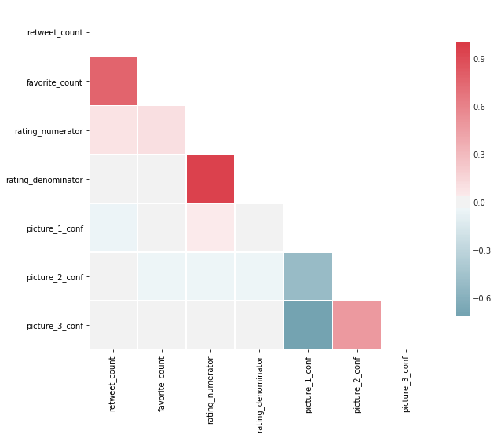

```python
# This is taken from
# https://seaborn.pydata.org/examples/many_pairwise_correlations.html

# Draw a heatmap for the correlation matrix

mask = np.zeros_like(corr, dtype=np.bool)
mask[np.triu_indices_from(mask)] = True

# Set up the matplotlib figure
f, ax = plt.subplots(figsize=(12, 8))

# Generate a custom diverging colormap
cmap = sns.diverging_palette(220, 10, as_cmap=True)

# Draw the heatmap with the mask and correct aspect ratio
sns.set_style('darkgrid')
sns.heatmap(corr, mask=mask, cmap=cmap, vmax=1, center=0,
            square=True, linewidths=.5, cbar_kws={"shrink": .8});
```

From the heatmap we can see:

- the retweet_count and favorite_count are highly correlated, in general user like to retweet the tweets they like, and vice versa.
- the correlaction between rating_numerator and favorite_count is not highly correlated, this might because we have some extreme value in the dog ratings.
- the rating_denominator and rating_numerator are highly positively correlated. This is more close to user habit. Usually user will give 11/10 instead of 11/100.
- dog prediction confidence level from picture_1 and picture_3 are negatively correlated. Is there any reason for this?

#### 2. Let's futher look at the dog analysis, see if dog rating has correlations with favorite_counts.

Compared with directly using rating_numerator data, which has a lot outliers and not standard. We created an additional column called standard_rating, help standardize the rating score based on different rating_denominators.

```python
# Creat new columns to standardize the dog rating
tweeter_df['standard_rating'] = tweeter_df['rating_numerator']/tweeter_df['rating_denominator']
```

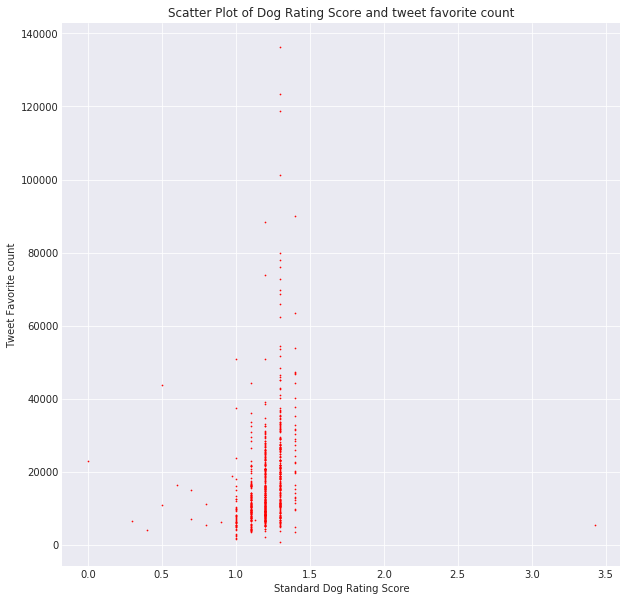

```python
# Create scatter plot to see the correlation between standard_rating and favorite_counts.
plt.figure(figsize=(10, 10))
plt.xlabel('Standard Dog Rating Score')
plt.ylabel('Tweet Favorite count')
plt.plot(tweeter_df.standard_rating, tweeter_df.favorite_count, color = 'red',
           linestyle='', marker='o', markersize=0.7)
plt.title('Scatter Plot of Dog Rating Score and tweet favorite count');
```

We can see in general the higher dog rating will get a higher favorite_counts, however the outliers where favorite_counts more thant 60000 are not the highest rating score.

#### 3. Then let's analysis what stage of the dog is highly rated and highly favorited.

```python
# Compare average favorite counts each dog stage
tweeter_favorite_avg = tweeter_df.groupby('dog_stage')['favorite_count'].mean().reset_index()
tweeter_favorite_avg
```

|  | dog_stage | favorite_count |
| --- | --- | --- |
| 0 | doggo | 18044.803922 |
| 1 | floofer | 20105.750000 |
| 2 | pupper | 17357.304348 |

Let's first compute the average favorite count per each dog stage category and draw a bar chart to visualize result.

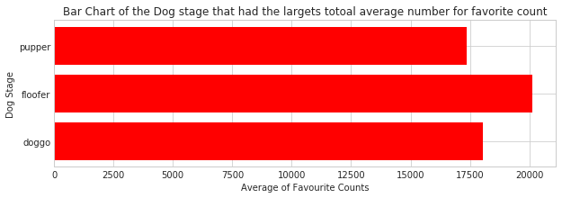

```python
#plot dog stage with average_favorite_counts
sns.set_style('whitegrid')
plt.figure(figsize = (10,3))

plt.barh(range(len(tweeter_favorite_avg.dog_stage)),tweeter_favorite_avg.favorite_count,color = 'red')
plt.yticks(range(len(tweeter_favorite_avg.dog_stage)),tweeter_favorite_avg.dog_stage)
plt.xlabel('Average of Favourite Counts')
plt.ylabel('Dog Stage')
plt.title('Bar Chart of the Dog stage that had the largets totoal average number for favorite count')
plt.show();
```

#### In general, floofer has highest average favorite counts. The other two stage are closer lower.

Then let's do similar thing to analysis standard rating with different dog stage

```python
# Compare average favorite counts each dog stage
tweeter_rate_avg = tweeter_df.groupby('dog_stage')['standard_rating'].mean().reset_index()
tweeter_rate_avg
```

|  | dog_stage | standard_rating |
| --- | --- | --- |
| 0 | doggo | 1.186301 |
| 1 | floofer | 1.180000 |
| 2 | pupper | 1.074900 |

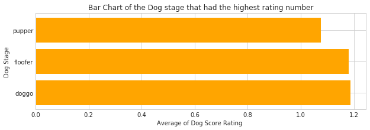

```python
#plot dog stage with average_rating_counts
sns.set_style('whitegrid')
plt.figure(figsize = (10,3))

plt.barh(range(len(tweeter_rate_avg.dog_stage)),tweeter_rate_avg.standard_rating,color = 'orange')
plt.yticks(range(len(tweeter_rate_avg.dog_stage)),tweeter_rate_avg.dog_stage)
plt.xlabel('Average of Dog Score Rating ')
plt.ylabel('Dog Stage')
plt.title('Bar Chart of the Dog stage that had the highest rating number')
plt.show();
```

#### And from the rating, we can see floofer and doggo has closely higher rating than pupper.

## Conclusion

In this project, we gather data from mutiple datasorece regarding to tweeter WeRateDogs. After wrangling data, access data to identify the tidiness and quality issue, we clean the data.

In data analysis and visualization part,we are not surprisingly found tweet's retweet and favorate counts are positively correlated. And when we look into dog stage, we can conclude ingeneral floofer would be more popular than the other two stage.

Although we take some efforts to clean the data, there's still a large portion of missing value in the dataframe. In future we could revisit each tweet text to recheck if we could do more to improve the data quality.

```python
from IPython.display import HTML
```

```python
HTML('''<script>
code_show=true;
function code_toggle() {
 if (code_show){
 $('div.input').hide();
 } else {
 $('div.input').show();
 }
 code_show = !code_show
}
$( document ).ready(code_toggle);
</script>
The raw code for this IPython notebook is by default hidden for easier reading.
To toggle on/off the raw code, click <a href="javascript:code_toggle()">here</a>.''')
```

The raw code for this IPython notebook is by default hidden for easier reading. To toggle on/off the raw code, click here.